# DAT 500 - Final Project

Author

Hanna Koul & Nuzaif Naveed

## Introduction

This project analyzes two public data sets from the City of Buffalo’s Open Data Portal: **Code Violations** and **Permits**.

The **Code Violations** data set contains approximately 195,000 records of reported housing and building violations, ranging from 2016 through mid-2025. Each record includes information about the violation and the parcel of property it occurred on.

The **Permits** data set includes around 166,000 building permit records, covering the time period from 2007 through 2025. It provides details on the type of permit issued, as well as the piece of real estate the project is taking place on.

This report focuses on exploring the trends in the data across Neighborhoods and Time. The original hypothesis for the project was that there is a relationship between real estate owners committing code violations and obtaining permits to subsequently improve the property. The findings of the report may still be used in researching this matter, by way of minimizing unimportant correlations and focusing on specific neighborhoods as particularly interesting case studies.

## Data Cleaning

We begin by clearing the R environment to ensure a fresh session, then loading necessary packages from the tidyverse for data manipulation, visualization, and date handling. Next, we import the two data sets — Code Violations and Permits — as CSV files into R for cleaning and analysis.

##### Preview of Code Violations Data Set

| Unique Key | Case Number | Date | Case Type | Status | Code | Code Section | Description | Comments | Inspector | Violation Location | Prop Class | SBL | Address | City | State | Zip | Neighborhood | Council District | Council District 2011 | Police District | Latitude | Longitude | Location | Census Tract | Census Block Group | Census Block | 2010 Census Tract | 2010 Census Block Group | 2010 Census Block | … |
| --- | --- | --- | --- | --- | --- | --- | --- | --- | --- | --- | --- | --- | --- | --- | --- | --- | --- | --- | --- | --- | --- | --- | --- | --- | --- | --- | --- | --- | --- | --- |
| 341739 | GEN22-9508330 | 07/07/2022 12:00:00 AM | GENERAL | CLOSED | IPMC-301.3 | Exterior Property Areas | Vacant structures and land | The city is requiring a letter of intent for the property. | JUSTIN KENDALL | NA | 220 | 1103500002014000 | 322 TRENTON | BUFFALO | NY | 14201 | NA | UNKNOWN | NA | NA | NA | NA | NA | NA | NA | NA | NA | NA | NA | … |
| 140456 | GEN16-9420984 | 09/19/2016 12:00:00 AM | GENERAL | ACTIVE | PM-304.6 | Property Maintenance | EXTERIOR WALLS | NA | ED FULLAGAR | NA | 0 | NA | 115 KAMPER | BUFFALO | NY | 14210 | Seneca-Cazenovia | SOUTH | SOUTH | District A | 43.00000 | -79.0000 | POINT (-78.80591252702546 42.85698889562538) | 10 | 5 | 5008 | 10 | 5 | 5010 | … |
| 334030 | GEN22-9503941 | 04/29/2022 12:00:00 AM | GENERAL | CLOSED | B103.11B | Buffalo Ordinance | PLAN MUST BE FILED ALT/REPAIR | PLANS ARE REQUIRED FOR THE STRUCTURAL REPAIRS RAFTERS, TOP WALL PLATE, AND RIDGE BOARD. | MIKE DILLON | NA | 220 | 0774800002017000 | 28 CONDON | BUFFALO | NY | 14207 | NA | UNKNOWN | NA | NA | NA | NA | NA | NA | NA | NA | NA | NA | NA | … |
| 292048 | GEN20-9486751 | 10/15/2020 12:00:00 AM | GENERAL | COMPLIED | IPMC-302.4 | Exterior Property Areas | Weeds | High weeds must be cut in the rear yard if the property is not maintained in 10 days tickets will be issued. | KEVIN GOULD | NA | 220 | 1103500002014000 | 322 TRENTON | BUFFALO | NY | 14201 | NA | UNKNOWN | NA | NA | NA | NA | NA | NA | NA | NA | NA | NA | NA | … |
| 335718 | GEN22-9504545 | 05/17/2022 12:00:00 AM | GENERAL | CLOSED | IPMC-304.9 | Exterior Structure | Overhang extensions | Rotted fascia | ROBERT ROMAN | NA | NA | NA | 911 SOUTH PARK | BUFFALO | NY | 14210 | First Ward | LOVEJOY | FILLMORE | District A | 42.86623 | -78.8481 | POINT (-78.84809681077357 42.866226100338146) | 5 | 1 | 1003 | 5 | 1 | 1027 | … |
| 135084 | GEN16-9419246 | 07/27/2016 12:00:00 AM | GENERAL | COMPLIED | PM-302.4 | Property Maintenance | WEEDS | NA | STEVEN PIERI | NA | 0 | NA | 157 PARKVIEW | BUFFALO | NY | 14210 | Seneca-Cazenovia | SOUTH | SOUTH | District A | 43.00000 | -79.0000 | POINT (-78.80312746799449 42.85133041778924) | 10 | 1 | 1006 | 10 | 1 | 1005 | … |

##### Preview of Permits Data Set

| Permit Number | Permit Type | Issued | Address | City | State | Zipcode | Applicant | Contractor License Number | License Type | Fees | Value of Work | Plans Submitted | SBL | Land Use | Inspector | Expiration Date | Description of Work | Units added | Units Lost | Location | Latitude | Longitude | Council District | Council District 2011 | Police District | Census Tract | Census Block Group | Census Block | Neighborhood | … |
| --- | --- | --- | --- | --- | --- | --- | --- | --- | --- | --- | --- | --- | --- | --- | --- | --- | --- | --- | --- | --- | --- | --- | --- | --- | --- | --- | --- | --- | --- | --- |
| 201003 | REPAIR | 09/27/2013 | 90 INWOOD | BUFFALO | NY | 14209 | R.N. CONSTRUCTION | NA | NA | 110 | 9765 | 0 | 0896300004028000 | 220 | NONE | NA | kitchen remodel, window kitchen reduction, drywall as needed to kitchen. | NA | NA | NA | 43 | -79 | DELAWARE | DELAWARE | District D | 63.02 | 3 | 3000 | Elmwood Bidwell | … |
| REP19-9498414 | REPAIR | 10/29/2019 | 130 WALLACE | BUFFALO | NY | 14216 | MICHAEL KELLY | LTC19-10052538 | LIGHT COMMERCIAL CONTRACTOR | 100 | 3000 | 3 | 0787400003019000 | 210 | PAUL BANYI | 04/29/2020 | REMOVAL OF 1 BEARING WALL PLANS FILED CALL MELISSA AT 716-983-7394 | NA | NA | NA | 43 | -79 | DELAWARE | DELAWARE | District D | 48 | 2 | 2003 | North Park | … |
| HEAT16-9415913 | HEATING | 04/11/2016 | 125 WASHINGTON | BUFFALO | NY | 14203 | JOHN SAMAR | HCQ15-10033622 | HEATING CONTRACTOR | 75 | 1000 | 0 | 1111700008003000 | 464 | MARK BLAKE | 10/11/2016 | HVAC WORK | NA | NA | NA | 43 | -79 | ELLICOTT | FILLMORE | District B | 165 | 1 | 1091 | Central | … |
| 154047 | PLUMBING | 05/11/2010 | 545 HIGHGATE | BUFFALO | NY | 14215 | RITTER & SENTRY PLUMBING SERV | 208195 | PLUMBERS MASTER | 30 | 0 | 0 | 0796600004011000 | 210 | NONE | NA | NEW HOT WATER TANK | NA | NA | NA | 43 | -79 | UNIVERSITY | UNIVERSITY | District E | 43 | 5 | 5003 | Kensington-Bailey | … |
| DEMO21-9543070 | DEMOLITION | 10/14/2021 | 342 CORNWALL | BUFFALO | NY | 14215 | JESMIN AKTER | NA | NA | 150 | 1000 | 0 | 0907100003017000 | 220 | SEAN MYERS | 04/14/2022 | OWNER PREVIOUSLY DEMOLISHED TO GRADE AND DISCARDED FROM THE PROPERTY THE DETACHED PRIVATE GARAGE IN THE REAR YARD AS PER OWNER. | NA | NA | NA | 43 | -79 | MASTEN | MASTEN | District E | 170 | 1 | 1007 | Delavan Grider | … |
| 227952 | REPAIR | 09/17/2015 | 48 NORMAN | BUFFALO | NY | 14210 | KCM CUSTOM BUILT GARAGES | NA | NA | 75 | 9700 | 0 | 1238200002049000 | 210 | NONE | NA | **ASBESTOS REPORT SCANNED - PASS** DEMO GARAGE AND BUILD NEW GARAGE AT 1-FAMILY, 2-STORY DWELLING. SEE SCANNED SKETCH AND CONTRACT. CONTACT KEVIN 694-9822 | NA | NA | NA | 43 | -79 | SOUTH | SOUTH | District A | 10 | 5 | 5008 | Seneca-Cazenovia | … |

The date columns in both datasets were initially stored as character strings, which limited their usefulness for time-based analysis. To address this, the relevant columns were converted to appropriate date or date-time formats using functions from the lubridate package. In the Code Violations dataset, the Date column was parsed as a full timestamp (POSIXct), enabling detailed time analysis. From this, new columns were derived to extract the year, month, day, and a combined month-year (ViolationMY) format.

Similarly, in the Permits dataset, both the Issued and Expiration Date columns were converted into date format. For each, new columns were created to capture the year, month, day, and month-year (IssuedMY and ExpiredMY) to support grouped visualizations and trends over time.

To make the data sets more interpretable, we created a new categorical variable called Property_Type in both data sets. This variable was derived from the numerical property classification codes: “Prop Class” in the Code Violations data set and “Land Use” in the Permits data set. These codes were grouped into broader categories such as Residential, Commercial, Industrial, and others, based on standard classification ranges. This transformation allows for easier comparison and visualization of trends across different types of properties.

In the Code Violations data set, the “Code” column includes a combination of letters and numbers that reference various legal or regulatory codes. To categorize these, we extracted the alphabetic portion at the beginning of each code into a new variable called “Code_System”. We then used this to create a new descriptive variable, “Code_Type”, which assigns meaningful labels such as “Property Maintenance – NY State” or “Building Code” based on the code prefix. This makes the data easier to understand and analyze by grouping violations under broader regulatory categories.

The “Permit Type” variable in the Permits data set contains a wide range of categories, many of which appear infrequently. To simplify analysis and visualization, we grouped less common permit types—those making up less than 1% of total permits under a single category labeled “Other.” This approach helps focus on the most relevant permit types while maintaining interpretability. Below, the “before” and “after” of this process can be viewed.

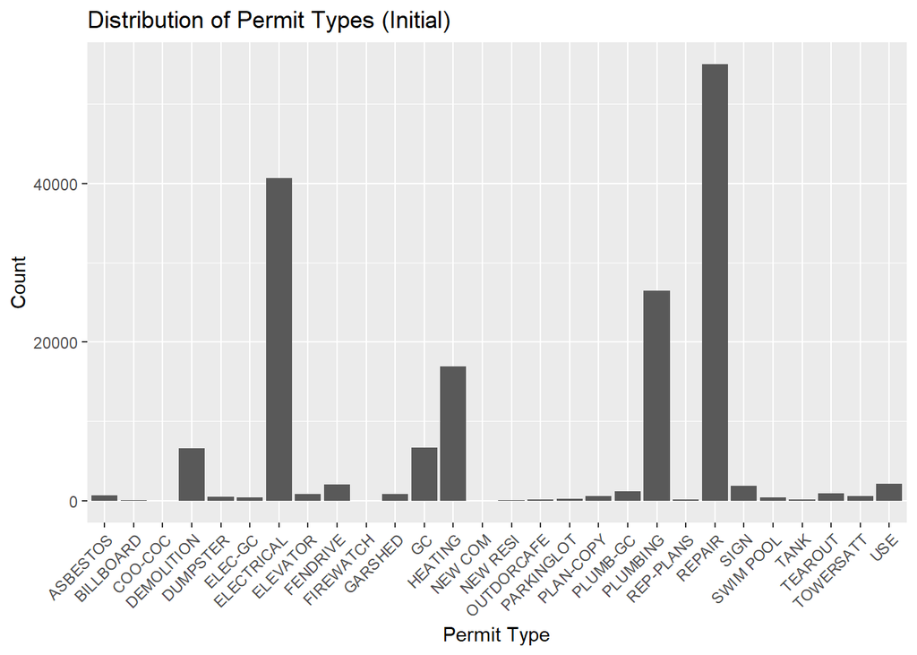

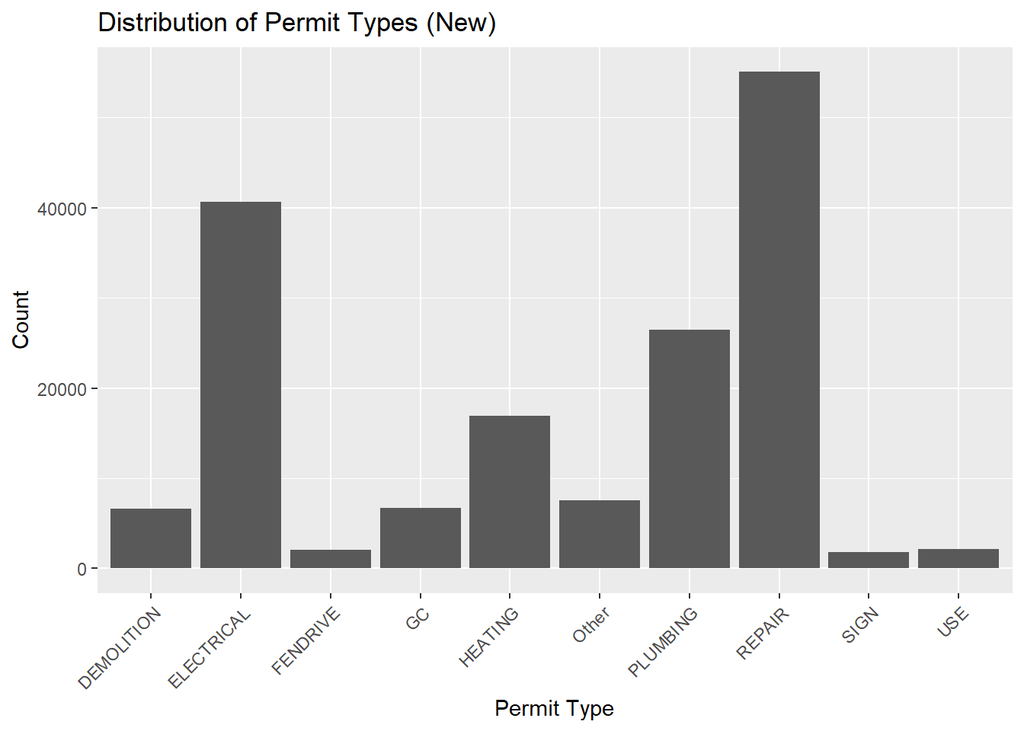

Several key categorical variables in both data sets such as “Property Type”, “Neighborhood”, and “Code Type” were converted to un-ordered factors. This ensures that R treats them as categorical variables during analysis and visualization, improving the clarity and accuracy of grouped summaries, plots, and model interpretations.

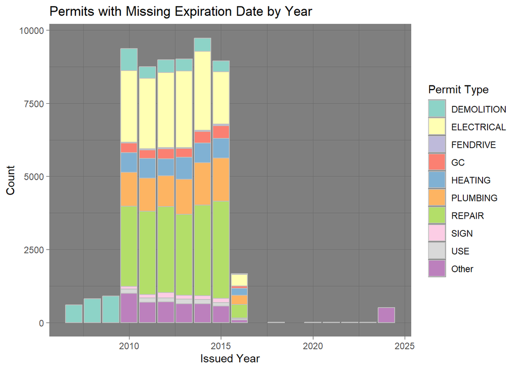

This plot highlights the temporal distribution of permits missing their expiration dates. The fact that in the years before 2016, nearly 100% of the recorded issued permits do not have expiration dates speaks to a change in the way the information about permits was recorded, as opposed to an inherent quality of those permits. Thus, this data will still be included in further exploration, and this is merely a curiosity.

## Permit Types Across Neighborhoods

First, we take a look at how many permits were issued per neighborhood, and their types. In order to accomplish this, we decided to use a horizontal bar plot, to retain readability for the names of the neighborhoods.

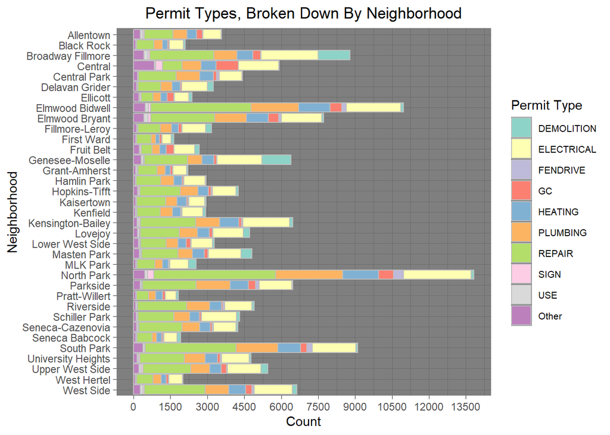

From this plot, it can be seen that some neighborhoods are quite a lot more prolific with regards to permits issued in them. Perhaps it would be useful to separate out those neighborhoods and examine both in more detail.

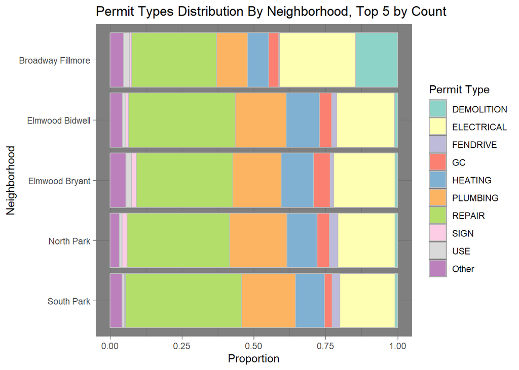

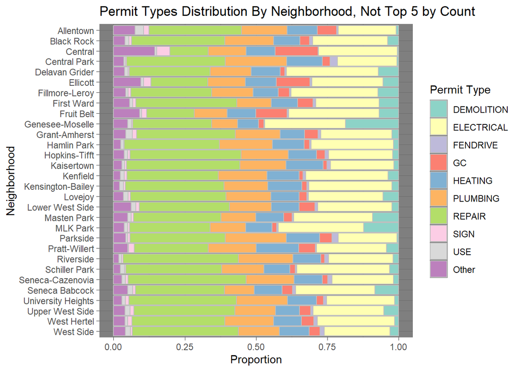

There do not seem to be any obvious differences in the distribution of permit types between the neighborhoods in the “Top 5 by Count” group and those outside of it. It can, however, be concluded that “Electrical”, “Plumbing”, “Heating”, and “Repair” are the most issued type of permit. Also of interest is that “General Construction” does not seem to be high in neighborhoods with a higher proportion or count of “Demolition”.

## Violation Types Across Neighborhoods

Similarly, we examine the distribution of violation types across the neighborhoods.

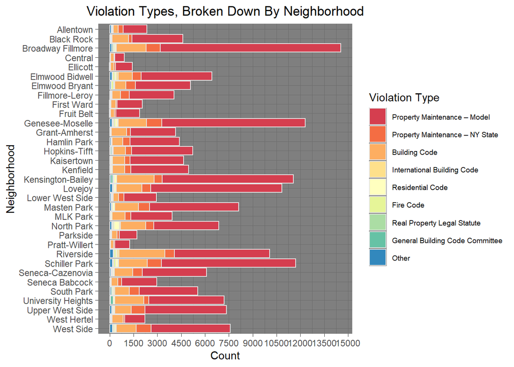

Here, there is also a number of neighborhoods with a notably high count of violations.

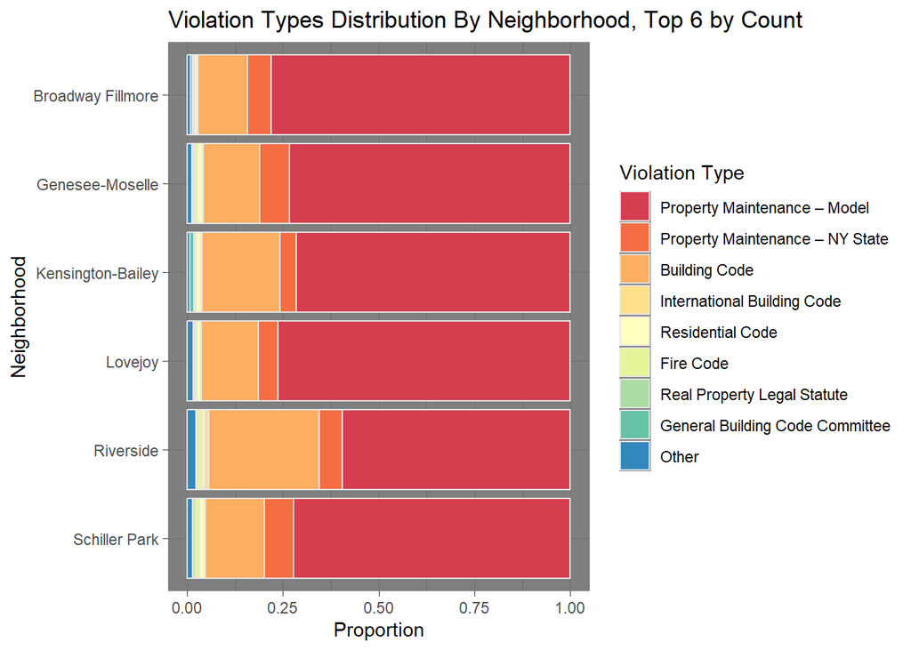

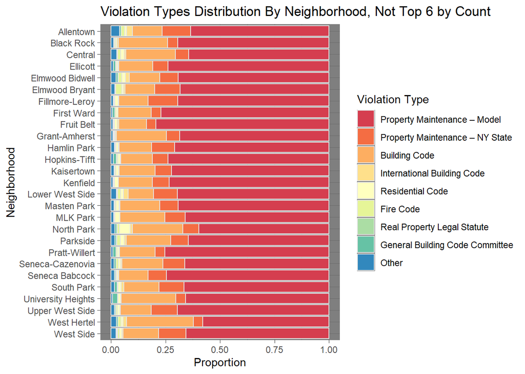

And again, the types of violations committed do not seem to be related to the total amount of violations in a neighborhood. We can derive from these plots that the overwhelming majority of violations are in “Property maintenance” (of both types) and “Building Code”.

## Is There A Relatonship Between Property Types and Code Violation Types?

To answer this question, the most obvious method is to create a heat map. To make the results more readable, the gradient has been made sharper by using a log function to concentrate the results, without affecting the actual frequencies mapped.

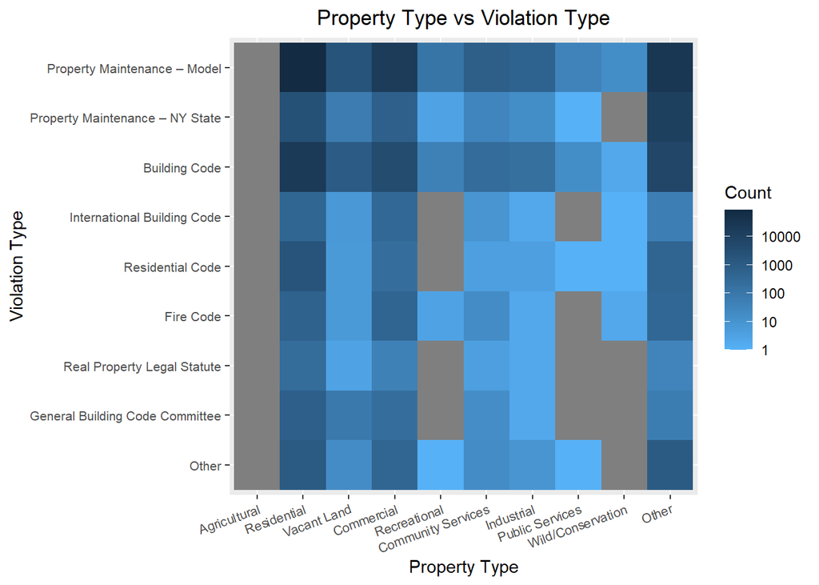

## Permit Fees and Value of Work Per Neighborhood

Of interest to us is the distribution of Fees and Value of Work in the Neighborhoods examined, to find, perhaps, a link between the amount of code violations and issued permits and the cost/value of doing work in those areas. The Neighborhoods highlighted in red are the ones with the most permits issued, the ones in blue are the ones with the most violations, and Broadway Fillmore is purple because it is both. It must also be noted that while there is a large amount of outliers shown, there are even more residing beyond the plot’s limits. We will be looking at the “box” part of the boxplots, to examine the median.

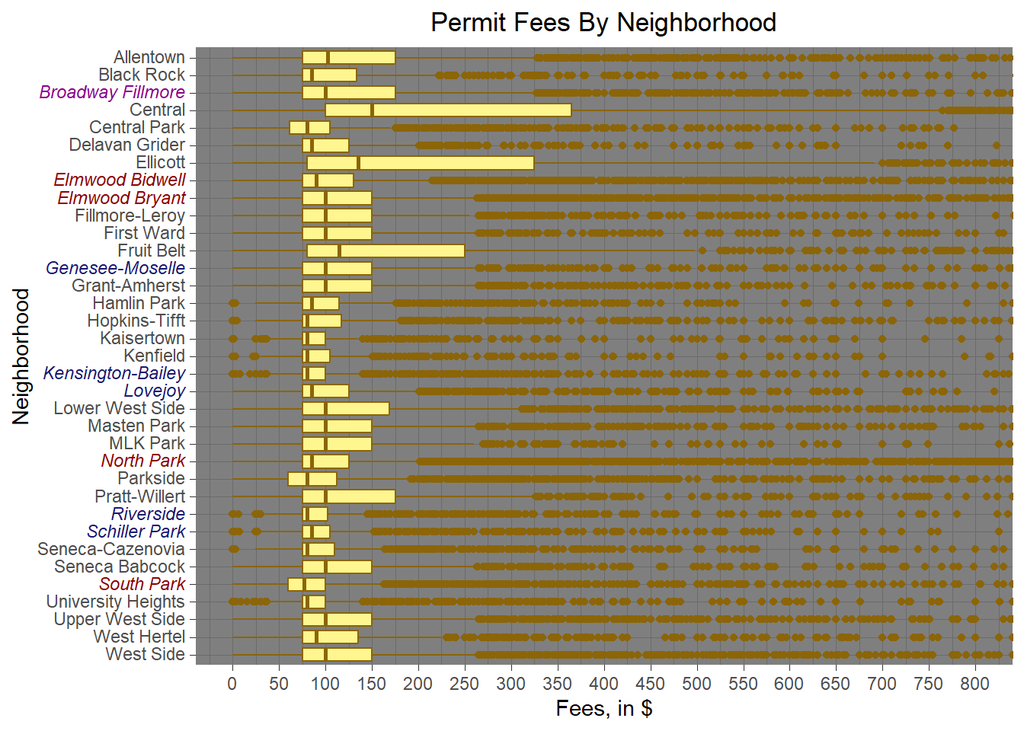

The original hypothesis for this section was that high average fees may be related to a lack of projects in a neighborhood, and vice versa. It does seem that the neighborhoods with the most permits have among the lowest median fees, there doesn’t seem to be a strong relationship there.

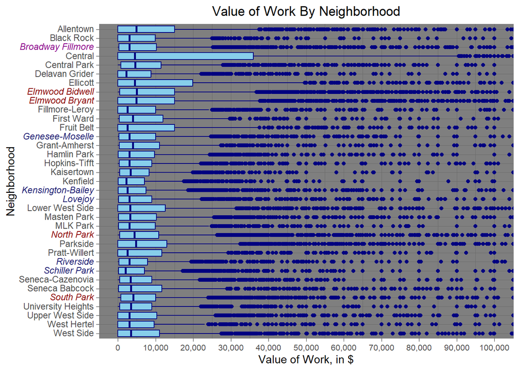

There doesn’t seem to be an obvious relationship here, either. It is interesting to note the high fees and value of work in the Central neighborhood, however. Makes sense, as it is the heart of downtown.

## Are There Relationships Between Permit Fees, Value of Work, and Permit Type?

To answer this question, we will create a scatter plot of these variables, and limit it slightly less than the previous two, in order to observe more data and demonstrate just how much of it lies beyond the IQR.

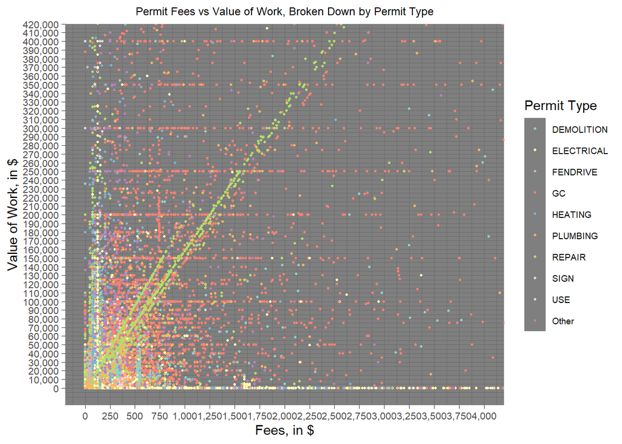

The only real takeaways available from this plot is 1. the General Construction projects are often valued at multiples of 50,000 and 2. there seem to be three or more linear relationships between fees and value of work on Repair projects.

## Time Trends of Permits Issued and Violations Committed

The last point of interest is the distribution of Permits and Violations across time. This can be examined with some line graphs, to look both at the general trend across the entire recorded period, and any potential seasonality, by examining cumulative occurrences by month. Please note, the colors are of the plots are entirely consistent with the previous plots. This section of plots is also faceted by count, to improve readability.

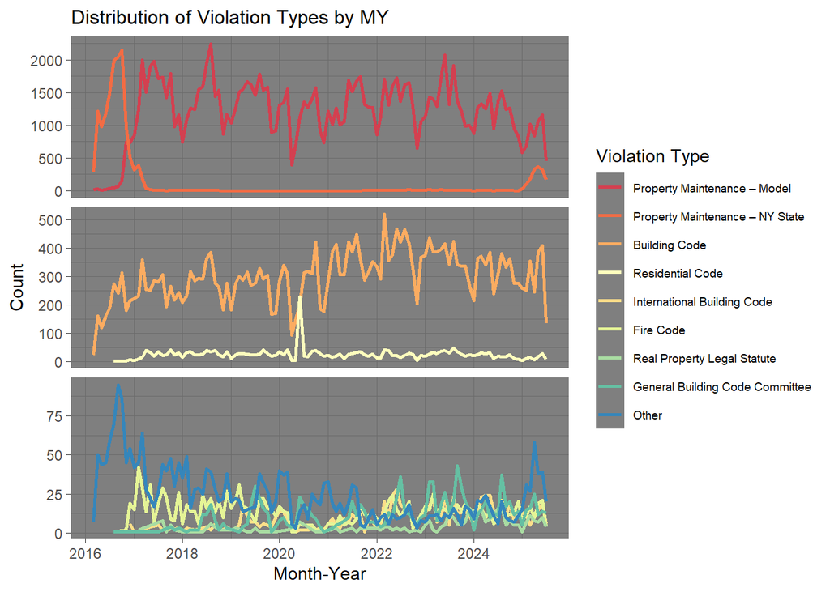

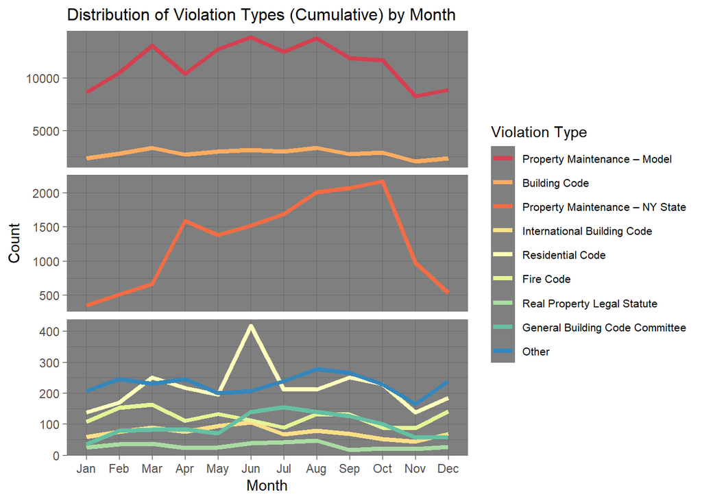

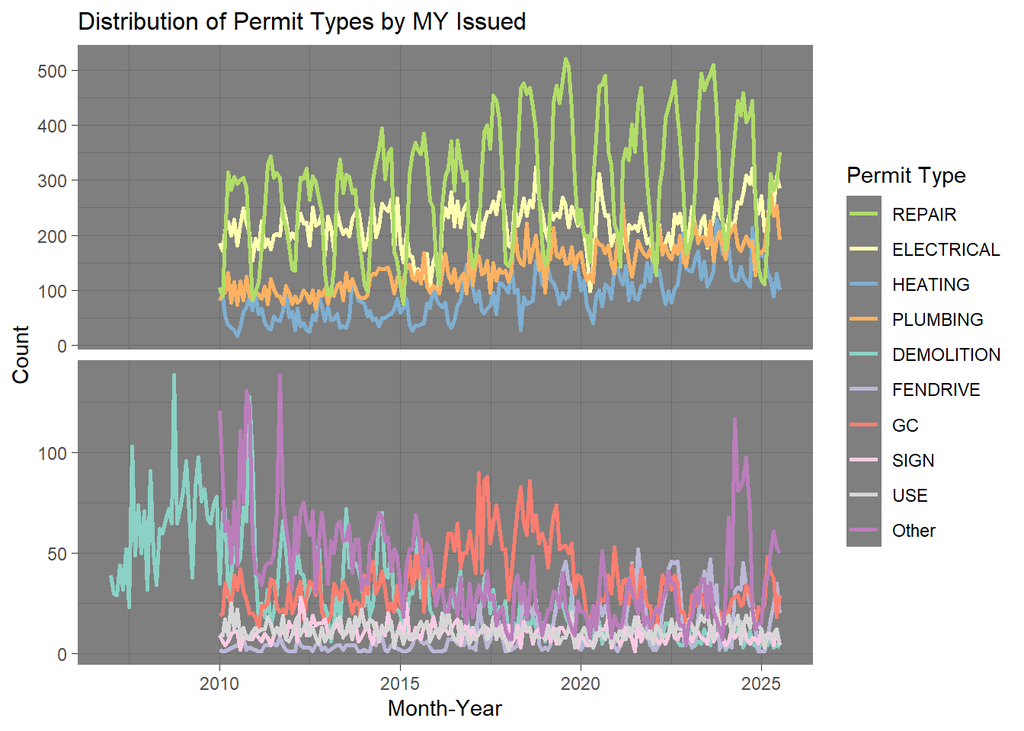

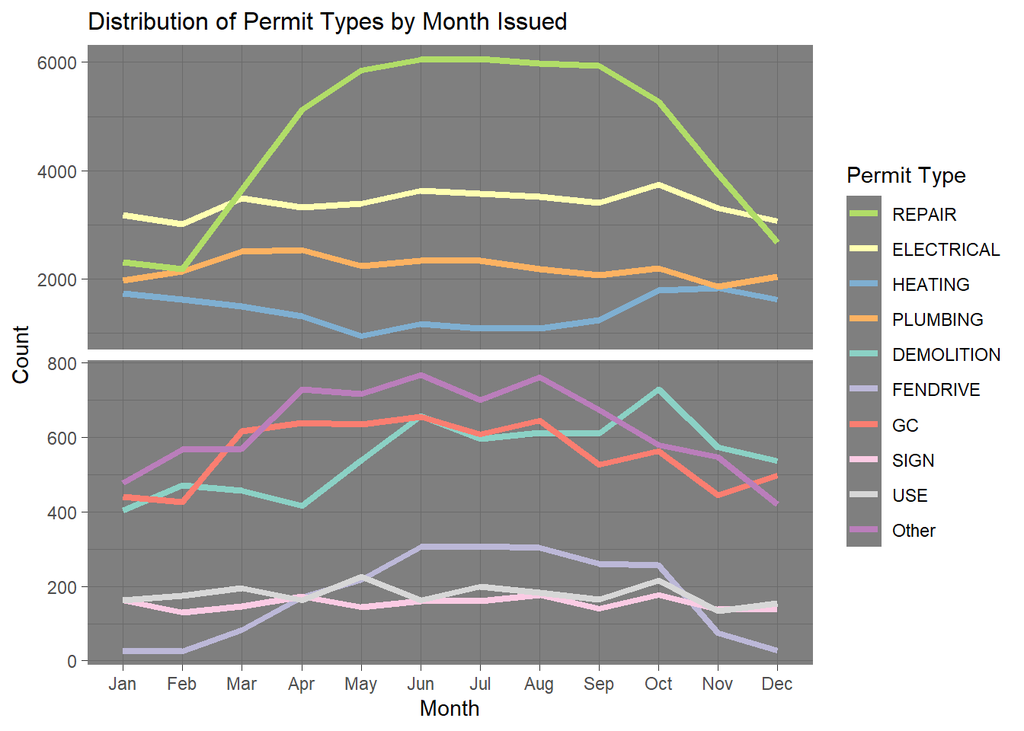

This plot demonstrates that the “outside” construction work is very seasonal, while the “indoor” type is less so. This is sharply obvious in the top facet of the plot. It is interesting that the “Heating” permits have an opposite seasonality to “Repair” and other “outside” types, due to one only noticing the lack of heating when it is too cold to do other construction.